# Simple Lineare Regression

[figure not shown]

Auf dieser Seite findest du Übungen zu Einfacher Linearer Regression in R.

Der gesamte Code, den du hier findest, kann von dir 1:1 in R umgesetzt werden. Die größte Lernwirkung hat diese Einführung, wenn du möglichst alles einmal selbst in R durchführst.

# 01 Vorbereitungen

Bevor wir loslegen können, müssen wir die Packages laden, die wir für unser Vorhaben benötigen. Zunächst ist das nur das `SfL` Package. Falls du dieses noch nicht geladen hast, hole dies nun nach:

```r
library(SfL)
```

Nun laden wir die Datensätze, die wir nutzen werden:

```r
data(data_a)
data(data_s)
data(data_v)
```

# 02 Einführung

Einfache Lineare Regression wird in R mit dem `lm()` Befehl umgesetzt. Dieser wird genutzt, um zu definieren, welche zwei Variablen voneinander abhängig modelliert werden sollen.

Hierbei orientiert man sich am besten an der allgemeinen Formel für Einfache Lineare Regression:

$$Y=\beta_1+\beta_2X+\epsilon$$

Hierbei beschreibt $Y$ die Variable, welche wir modellieren, d.h. vorhersagen, möchten. $X$ ist die Variable mit welcher wir $Y$ vorhersagen möchten. $\beta_1$ ist der Y-Achsenabschnitt, d.h. das Intercept, unserer Regressionsgeraden, und $\beta_2$ ist die Steigung, d.h. der Slope, der Regressionsgeraden.

# 03 Modelling

Als Beispiel erstellen wir nun ein Einfaches Lineares Modell für die Dauer von /s/. Vorhergesagt werden soll die Dauer durch die Sprechgeschwindigkeit. Wichtig ist auch bei Regressionsmodellen, dass die abhängige Variable möglichst normalverteilt ist. Daher überprüfen wir dies im nächsten Schritt.

## Überprüfung der Verteilung

Wie wir bereits in vorherigen Sessions gesehen haben, ist `sDur` nicht normalverteilt:

```r
shapiro.test(data_s$sDur)
```

```
    Shapiro-Wilk normality test

data:  data_s$sDur
W = 0.93622, p-value = 2.761e-06
```

Wir nutzen daher eine log-transformierte Version der Variable als abhängige Variable im weiteren Vorgehen:

```r
data_s$sDurLog <- log(data_s$sDur)
```

## Modell-Erstellung

Nun erstellen wir das Modell:

```r
lineares.modell1 <- lm(sDurLog ~ speakingRate, data = data_s)
```

Regressionsmodelle sollten immer als Objekt gespeichert werden. Daher nennen wir dieses erste Modell `lineares.modell1`. So ist sichergestellt, dass wir das Modell auch mit weiteren Funktionen nutzen können.

## Koeffizienten

Nun schauen wir uns zunächst an, was R ausgibt, wenn wir das erstellte Modell abfragen:

```r
lineares.modell1
```

```
Call:
lm(formula = sDurLog ~ speakingRate, data = data_s)

Coefficients:
 (Intercept)  speakingRate
      -1.694        -0.121
```

Hier finden wir erneut die Formel zu unserem Modell sowie das genutze Datenset. Außerdem erhalten wir die **Coefficients**. Doch was beudeuten diese Angaben?

Beachte die folgende Darstellung, um `(Intercept)`- und `speakingRate`-Coefficients ungefähr wiederzufinden:

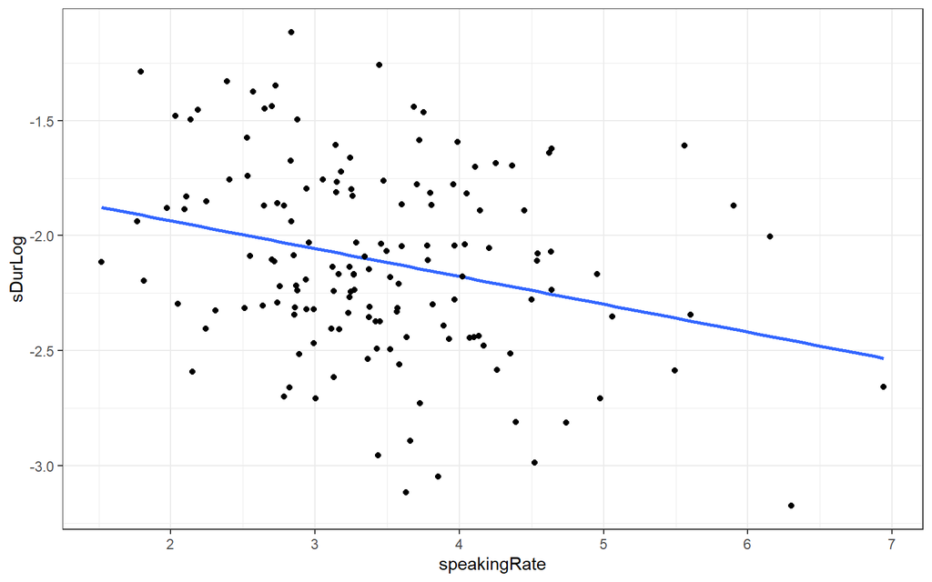